# Regression Homework - homework 2

Alisha Gumber

Fall 2019

# Lab Section

In this lab, we will go over regression. We will be using the caret package in R. https://topepo.github.io/caret/train-models-by-tag.html

# Perfomance Metrics

## Residual

Deviation of the observed value to the estimated value (sample mean)
$$residual=y_i - \hat{y_i}$$
where $\hat{y_i}$ is the estimated value

## Mean Squared Error (MSE)

$$MSE=\frac{1}{n}\sum_{i=1}^{n}(y_i - \hat{y_i})^2$$

## Root Mean Squared Error (RMSE)

Same units as original data.

$$RMSE=\sqrt{MSE}$$

## L2 regularization : Ridge regression. Regularize by adding the sum of the coefficients, squared, to the function.

$$Ridge Regression=\sum_{i=1}^{n}(y_i - w_0 - \sum_{j=1}^{p}w_jx_{ij})^2 + \lambda\sum_{j=1}^p(w_j)^2$$

## L1 regularization : Lasso Regression. Regularize by adding the sum of the absolute value of the coefficients to the model. Coefficient estimates may be pushed to zero – Lasso can perform variable selection

$$Lasso Regression=\sum_{i=1}^{n}(y_i - w_0 - \sum_{j=1}^{p}w_jx_{ij})^2 + \lambda\sum_{j=1}^p|w_j|$$

### The broad steps of Machine learning in R.

1. Split the data into training and test. Set test aside.
2. Fit a good model to the training data.
3. See how your model did on the training data.
4. Test how your model performs on the test data.

# Regression

```r
#View(airquality)
```

1. Split data into training and test set (75% in train set, 25% in test set)

```r
## 75% of the sample size

sample_size <- floor(0.75 * nrow(airquality))

## set the seed to make partition reproducible
set.seed(115)
training <- sample(seq_len(nrow(airquality)), size = sample_size)

train_regression = airquality[training, ]
test_regression = airquality[-training, ]
head(train_regression) # 114 observations
```

|  | Ozone | Solar.R | Wind | Temp | Month | Day |
| --- | --- | --- | --- | --- | --- | --- |
| 135 | 21 | 259 | 15.5 | 76 | 9 | 12 |
| 107 | NA | 64 | 11.5 | 79 | 8 | 15 |
| 62 | 135 | 269 | 4.1 | 84 | 7 | 1 |
| 76 | 7 | 48 | 14.3 | 80 | 7 | 15 |
| 82 | 16 | 7 | 6.9 | 74 | 7 | 21 |
| 34 | NA | 242 | 16.1 | 67 | 6 | 3 |

```r
head(test_regression) # 39 observatons
```

|  | Ozone | Solar.R | Wind | Temp | Month | Day |
| --- | --- | --- | --- | --- | --- | --- |
| 2 | 36 | 118 | 8.0 | 72 | 5 | 2 |
| 5 | NA | NA | 14.3 | 56 | 5 | 5 |
| 8 | 19 | 99 | 13.8 | 59 | 5 | 8 |
| 13 | 11 | 290 | 9.2 | 66 | 5 | 13 |
| 17 | 34 | 307 | 12.0 | 66 | 5 | 17 |
| 18 | 6 | 78 | 18.4 | 57 | 5 | 18 |

### Linear Regression

- Assumes a linear relationship.
- Independent variables should not be correlated (no mulitcollinearity)
- The number of observations should be greater than the number of independent variables.

$$RSS=\sum(y_i - \hat{y_i})^2$$
We will predict the response of the Temperature based on Wind.

This is the data we will fit a linear model to.

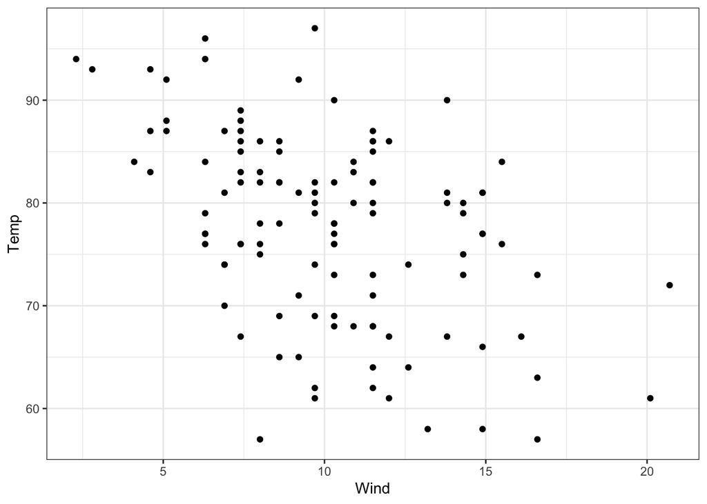

```r
# response of temp based on wind means y is dependent on x so x = wind (independent variable) and y = temp (dependent variable)
train_plot <- ggplot(data = train_regression) +
   geom_point(aes(x=Wind, y=Temp)) +
   theme_bw()
train_plot
```

2. Create and fit a linear model to predict Temperature from Wind using the training set

```r
#help(train)

linear_regression <- train(Temp ~ Wind, data=train_regression, method = "lm")
summary(linear_regression)
```

```
##
## Call:
## lm(formula = .outcome ~ ., data = dat)
##
## Residuals:
##     Min      1Q  Median      3Q     Max
## -23.207  -5.663   1.756   6.062  18.867
##
## Coefficients:
##             Estimate Std. Error t value Pr(>|t|)
## (Intercept)  89.9657     2.4091  37.344  < 2e-16 ***
## Wind         -1.2198     0.2255  -5.409 3.64e-07 ***
## ---
## Signif. codes:  0 '***' 0.001 '**' 0.01 '*' 0.05 '.' 0.1 ' ' 1
##
## Residual standard error: 8.295 on 112 degrees of freedom
## Multiple R-squared:  0.2071, Adjusted R-squared:    0.2
## F-statistic: 29.25 on 1 and 112 DF,  p-value: 3.638e-07
```

3. Vizualize how your model performed on the train data by plotting the regression line on top of the train data points.

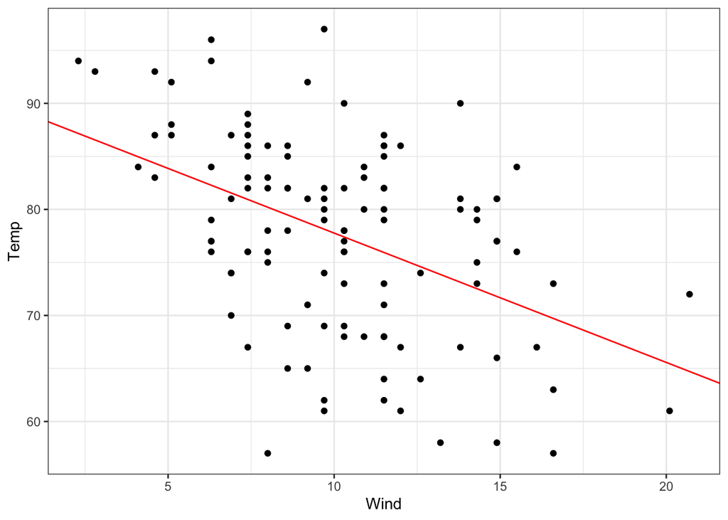

```r
# use intercept and slope values from summary of the linear regression model
# y = 89.9657 + -1.2198x
train_plot + geom_abline(intercept = 89.9657, slope = -1.2198, col="red")
```

```r
# + geom_smooth(method = 'lm', color=)
```

4. Explore how the model performs on the test data. For Linear Regression:
- The residuals should be close to zero.
- There should be equal variance around the regression line (homoscedasticity).
- Residuals should be normally distributed.
- Independent variables and residuals should not be correlated.

4 a) See how the model performs on the test data

```r
#help(predict)
linear_predict <- predict(linear_regression, test_regression)
linear_predict
```

```
##        2        5        8       13       17       18       21       30
## 80.20711 72.52224 73.13215 78.74333 75.32783 67.52098 78.13342 83.01270
##       35       42       44       46       53       54       63       64
## 78.74333 76.66963 80.20711 75.93774 87.89198 84.35450 78.74333 78.74333
##       69       70       75       86       93       96       99      101
## 82.28081 83.01270 71.79035 80.20711 81.54892 81.54892 85.08639 80.20711
##      102      111      113      114      115      117      119      124
## 79.47522 76.66963 71.05846 72.52224 74.59594 85.81829 83.01270 81.54892
##      132      133      134      137      139      146      150
## 76.66963 78.13342 71.79035 76.66963 81.54892 77.40153 73.86405
```

4 b) Look at the residuals. Are they close to zero?

```r
#look at the median residual value. Close to zero is best
summary(linear_regression)
```

```
##
## Call:
## lm(formula = .outcome ~ ., data = dat)
##
## Residuals:
##     Min      1Q  Median      3Q     Max
## -23.207  -5.663   1.756   6.062  18.867
##
## Coefficients:
##             Estimate Std. Error t value Pr(>|t|)
## (Intercept)  89.9657     2.4091  37.344  < 2e-16 ***
## Wind         -1.2198     0.2255  -5.409 3.64e-07 ***
## ---
## Signif. codes:  0 '***' 0.001 '**' 0.01 '*' 0.05 '.' 0.1 ' ' 1
##
## Residual standard error: 8.295 on 112 degrees of freedom
## Multiple R-squared:  0.2071, Adjusted R-squared:    0.2
## F-statistic: 29.25 on 1 and 112 DF,  p-value: 3.638e-07
```

**The median redidual is 1.756, which is pretty close to zero, but there is a relatively large range of residuals.**

```r
# on my own: calculating error
error <- linear_predict - test_regression$Temp
RMSE = sqrt(mean(error^2))
RMSE
```

```
## [1] 8.852811
```

4 c) Plot predicted temperature vs observed temperature. A strong model should show a strong correlation

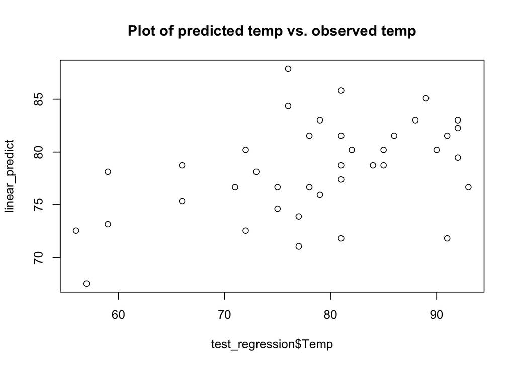

```r
plot(test_regression$Temp, linear_predict, main="Plot of predicted temp vs. observed temp")
```

```r
cor.test(test_regression$Temp, linear_predict)
```

```
##
##  Pearson's product-moment correlation
##
## data:  test_regression$Temp and linear_predict
## t = 3.1474, df = 37, p-value = 0.003249
## alternative hypothesis: true correlation is not equal to 0
## 95 percent confidence interval:
##  0.1684671 0.6769215
## sample estimates:
##       cor
## 0.4595567
```

4 d) Visualize the predicted values in relation to the real data points. Look for homoscedasticity

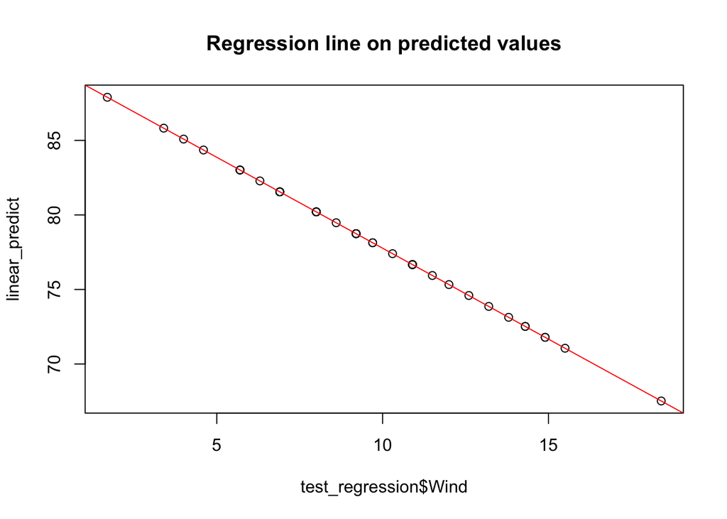

```r
# Extract coefficients from the model
coef1 <- linear_regression$finalModel$coefficients[1]
coef2 <- linear_regression$finalModel$coefficients[2]

# plot the regression line on the predicted values
plot(x=test_regression$Wind, y=linear_predict, pch=1, main="Regression line on predicted values")
abline(coef1, coef2, col="red")
```

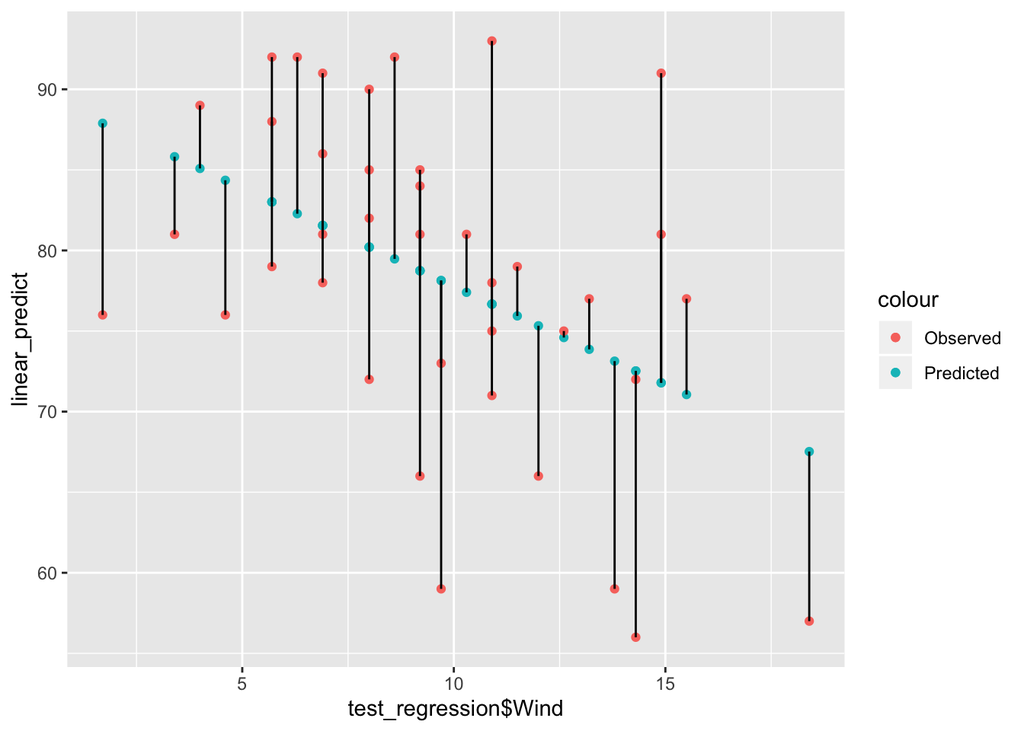

```r
# plot the original test values
ggplot(test_regression) +
  geom_point(aes(x=test_regression$Wind, y=linear_predict, col="Predicted")) +
  geom_point(aes(x= Wind, y= Temp, col="Observed")) +
  geom_segment(aes(x=Wind, y=Temp, xend=Wind, yend=linear_predict))
```

4 e) Residuals should be normally distributed. Plot the density of the residuals

```r
residuals_lin <- residuals(linear_regression)
head(residuals_lin)
```

```
##       X135       X107        X62        X76        X82        X34
##  4.9415421  3.0622597 -0.9644128  7.4777574 -7.5489151 -3.3265655
```

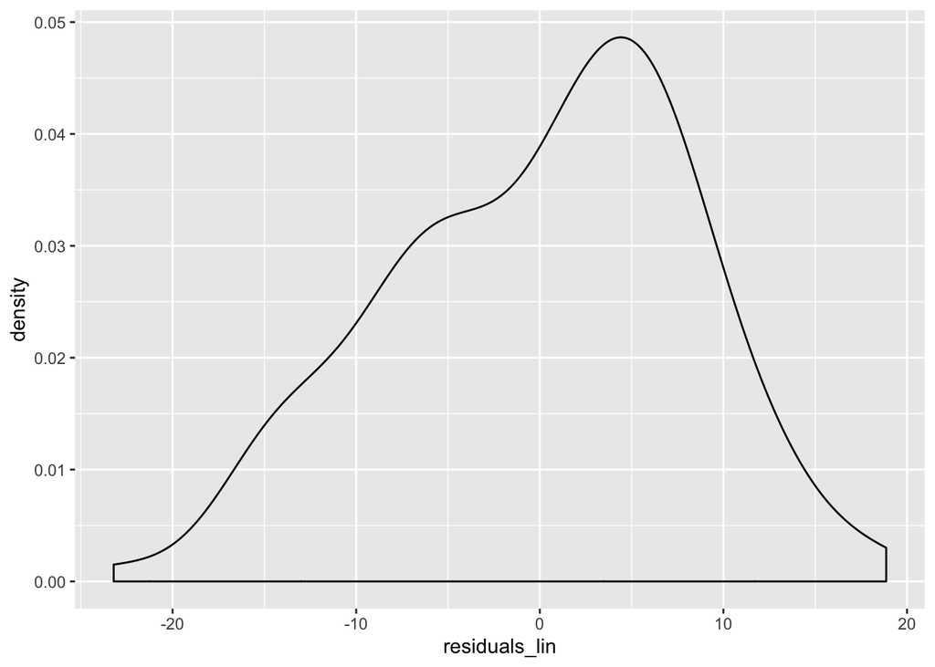

```r
ggplot(x=residuals_lin) +
  geom_density(aes(residuals_lin))
```

4 f) Independent variables and residuals should not be correlated

```r
cor.test(train_regression$Wind, resid(linear_regression))
```

```
##
##  Pearson's product-moment correlation
##
## data:  train_regression$Wind and resid(linear_regression)
## t = -5.9008e-16, df = 112, p-value = 1
## alternative hypothesis: true correlation is not equal to 0
## 95 percent confidence interval:
##  -0.1839148  0.1839148
## sample estimates:
##           cor
## -5.575717e-17
```

```r
# Correlation test shows indepdent variables and residuals are not correlated
```

### Linear Regression with Regularization

5. Create a linear model using L1 or L2 regularization to predict Temperature from Wind and Month variables. Plot your predicted values and the real Y values on the same plot.

```r
# cross validation with sample of 10 observations
control =  trainControl(method = "cv", 10)

# train model with ridge regression (L2)
ridge_regression <- train(Temp ~ Wind + Month, data = train_regression,
                          method = 'ridge', trControl= control)
ridge_regression
```

```
## Ridge Regression
##
## 114 samples
##   2 predictor
##
## No pre-processing
## Resampling: Cross-Validated (10 fold)
## Summary of sample sizes: 102, 103, 102, 103, 103, 102, ...
## Resampling results across tuning parameters:
##
##   lambda  RMSE      Rsquared   MAE
##   0e+00   7.742262  0.3063110  6.413867
##   1e-04   7.742261  0.3063117  6.413856
##   1e-01   7.741797  0.3069868  6.405881
##
## RMSE was used to select the optimal model using the smallest value.
## The final value used for the model was lambda = 0.1.
```

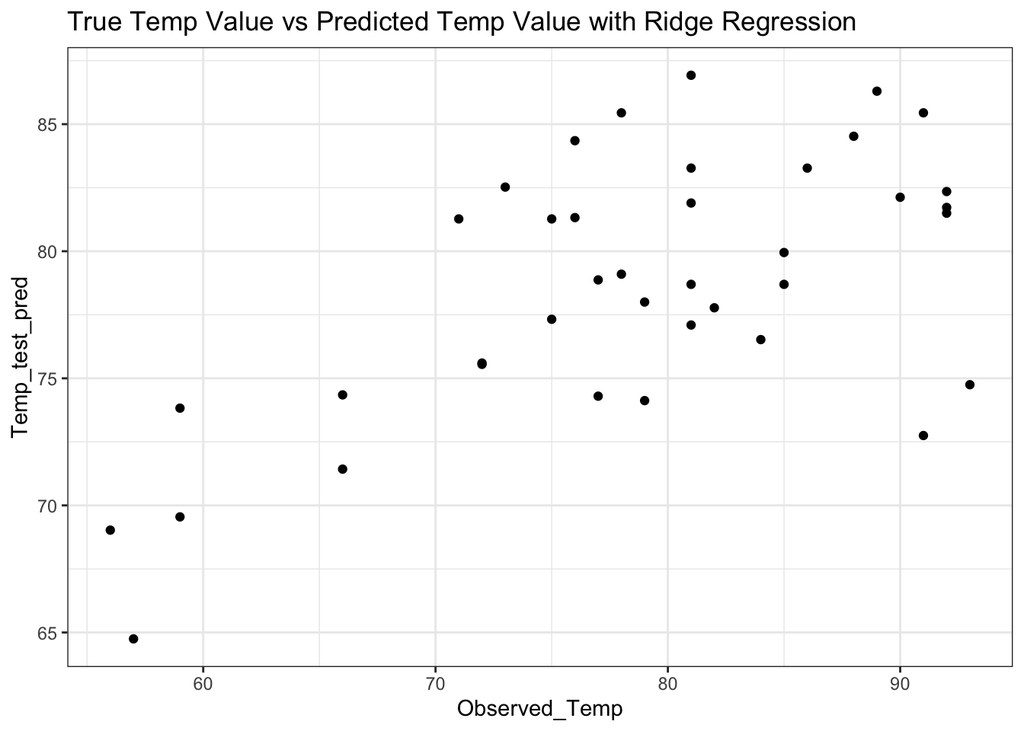

```r
# examine residuals
ridge_test_predict <- predict(ridge_regression, newdata = test_regression)

#plot the predicted values vs the observed values
plot_ridge_test_pred <- data.frame(Temp_test_pred = ridge_test_predict,
                                   Observed_Temp = test_regression$Temp)
ggplot(data = plot_ridge_test_pred) +
  geom_point(aes(x=Observed_Temp, y = Temp_test_pred)) +
  ggtitle("True Temp Value vs Predicted Temp Value with Ridge Regression") +
  theme_bw()
```

```r
#median residual value should be close to zero
median(resid(ridge_regression))
```

```
## [1] 0.1028533
```